# COMPSCI 415.2 Homework 3

Gregory Spathias

June 25, 2018

Homework Set-up

```r
library(tidyverse)
```

```r
library(ggplot2)
library(mdsr)
```

## **Section 3.8.1: all exercises**

### **3.8.1.1**

The problem with this plot is that it doesn’t represent the quantity of points correctly. In order to improve this plot we can add the argument of position = “jitter” to add random noise to each point to more accurately show the quantity of points graphed.

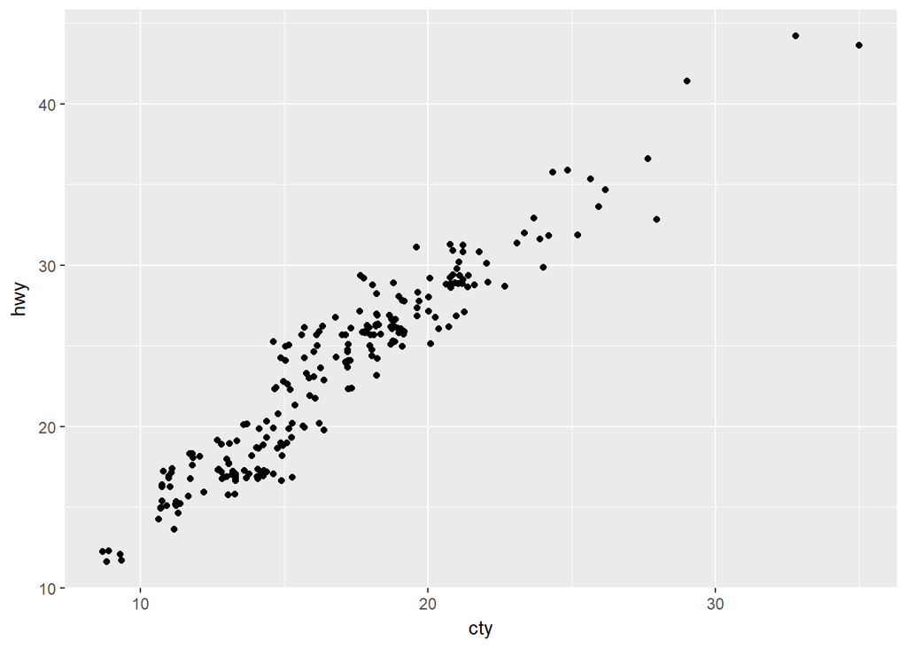

```r
ggplot(data = mpg, mapping = aes(x = cty, y = hwy)) + geom_point(position = "jitter")
```

### **3.8.1.2**

To control the amount of jittering with geom_jitter() you can use the paramters width and height.

### **3.8.1.3**

geom_jitter and geom_count - Similarities: both of these functions can be used to avoid overplotting in a plot. - Differences: geom_jitter adds random noise to each point so that points are not overlaid on top of one another. geom_count counts the number of points at each location then maps the count of points to the point area.

### **3.8.1.4**

The default position adjustment is position dodge.

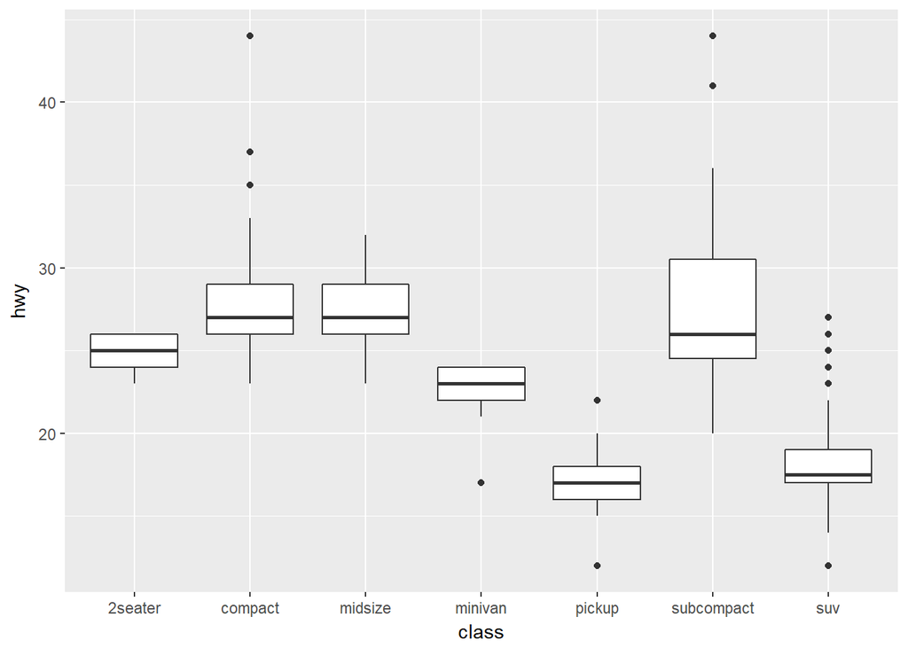

```r
ggplot(data = mpg, mapping = aes(x = class, y = hwy)) + geom_boxplot(position = 'dodge')
```

## **Section 3.9.1: #2 and #4 only**

### **3.9.1.2**

labs() modifies the axis, legend, and plot labels. This function allows you to set the titles of a plot, the axis labels, and captions.

### **3.9.1.4**

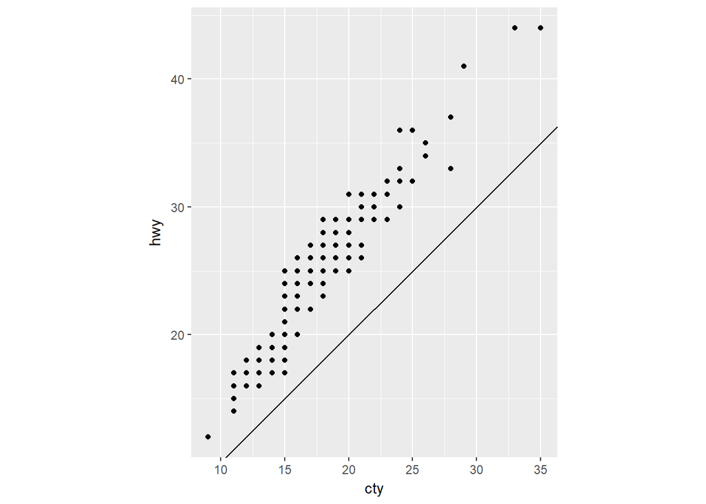

```r
ggplot(data = mpg, mapping = aes(x = cty, y = hwy)) +
  geom_point() +
  geom_abline() +
  coord_fixed()
```

This plot shows that city and highway mpg have a strong positive correlation. If a car has a high city mpg then it will have a high highway mpg. The coord_fixed() function forces a specified ratio between the physical representation of data units on the axes. This is important because it represents the number of units on the y-axis equivalent to a change in one unit of x. geom_abline() adds a reference line to a plot where you can specify the slope and intercept. The default is an intercept of 0 and a slop of +1.

## **Section 4.4: #1 and #2 only**

### **4.4.1**

This code doesn’t work because in the second my variable the “i” is not actually an i.

### **4.4.2**

Corrected code below

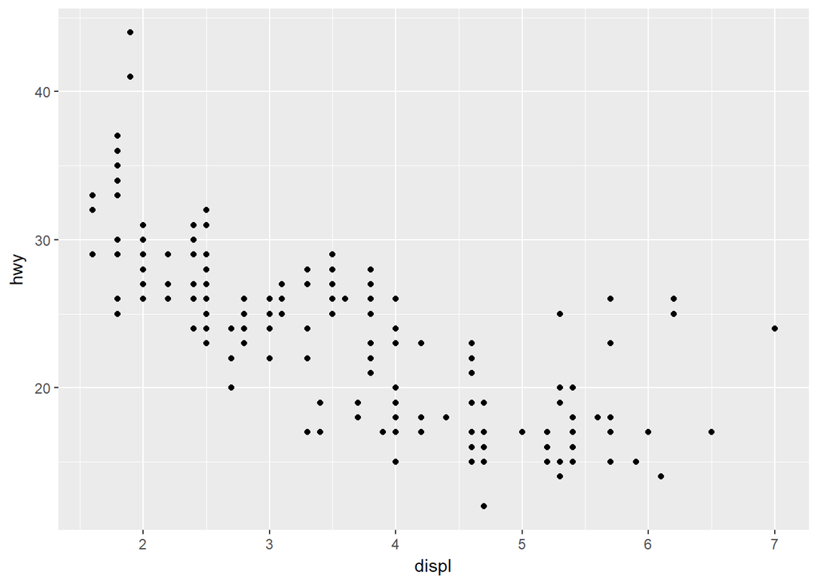

```r
library(tidyverse)
library(dplyr)

#changed dota to data
ggplot(data = mpg) +
  geom_point(mapping = aes(x = displ, y = hwy))
```

```r
filter(mpg, cyl == 8) #changed fliter to filter, changed "=" to "=="
```

```
## # A tibble: 70 x 11
##    manufacturer model     displ  year   cyl trans  drv     cty   hwy fl
##    <chr>        <chr>     <dbl> <int> <int> <chr>  <chr> <int> <int> <chr>
##  1 audi         a6 quatt~   4.2  2008     8 auto(~ 4        16    23 p
##  2 chevrolet    c1500 su~   5.3  2008     8 auto(~ r        14    20 r
##  3 chevrolet    c1500 su~   5.3  2008     8 auto(~ r        11    15 e
##  4 chevrolet    c1500 su~   5.3  2008     8 auto(~ r        14    20 r
##  5 chevrolet    c1500 su~   5.7  1999     8 auto(~ r        13    17 r
##  6 chevrolet    c1500 su~   6    2008     8 auto(~ r        12    17 r
##  7 chevrolet    corvette    5.7  1999     8 manua~ r        16    26 p
##  8 chevrolet    corvette    5.7  1999     8 auto(~ r        15    23 p
##  9 chevrolet    corvette    6.2  2008     8 manua~ r        16    26 p
## 10 chevrolet    corvette    6.2  2008     8 auto(~ r        15    25 p
## # ... with 60 more rows, and 1 more variable: class <chr>
```

```r
filter(diamonds, carat > 3) #changed diamond to diamonds
```

```
## # A tibble: 32 x 10
##    carat cut     color clarity depth table price     x     y     z
##    <dbl> <ord>   <ord> <ord>   <dbl> <dbl> <int> <dbl> <dbl> <dbl>
##  1  3.01 Premium I     I1       62.7    58  8040  9.1   8.97  5.67
##  2  3.11 Fair    J     I1       65.9    57  9823  9.15  9.02  5.98
##  3  3.01 Premium F     I1       62.2    56  9925  9.24  9.13  5.73
##  4  3.05 Premium E     I1       60.9    58 10453  9.26  9.25  5.66
##  5  3.02 Fair    I     I1       65.2    56 10577  9.11  9.02  5.91
##  6  3.01 Fair    H     I1       56.1    62 10761  9.54  9.38  5.31
##  7  3.65 Fair    H     I1       67.1    53 11668  9.53  9.48  6.38
##  8  3.24 Premium H     I1       62.1    58 12300  9.44  9.4   5.85
##  9  3.22 Ideal   I     I1       62.6    55 12545  9.49  9.42  5.92
## 10  3.5  Ideal   H     I1       62.8    57 12587  9.65  9.59  6.03
## # ... with 22 more rows
```

## **Section 5.2.4: #1, #3 and #4 only. You will need to install the nycflights13 package and use the flights data.**

```
install.packages("nycflights13")
```

### **5.2.4.1**

**1** Flights that had delay of two or more hours.

```
filter(flights, arr_delay >= 120)
```

**2** Flights that flew to Houston(IAH or HOU)

```
filter(flights, dest == 'IAH' | dest == 'HOU')
```

**3** Flights operated by United, American or Delta

```
filter(flights, carrier %in% c('UA','AA','DL'))
```

**4** Flights that departed in summer (July, August, and September)

```
filter(flights, month %in% c(7,8,9))
```

**5** Flights that arrived more than two hours late, but didn’t leave late

```
filter(flights, dep_delay <= 0 & arr_delay > 120)
```

**6** Flights that were delayed by at least an hour, but made up over 30 minutes in flight

```
filter(flights, dep_delay >= 60 & (dep_delay - arr_delay) > 30)
```

**7** Flights that departed between midnight and 6am (inclusive)

```
filter(flights, dep_time == 2400 | dep_time <= 600)
```

### **5.2.4.3**

```
filter(flights, is.na(dep_time))
```

8,255 flights. These are most likely flights that were scheduled, but never flew.

### **5.2.4.4**

- NA^0 is not missing because any number to the 0th power is equal to 1.
- NA | True because as long as one condition of an “or” statement is true, the result will be true
- False & NA is not missing because NA is a missing value for the “and” statement ignores it
- NA*0 is missing because you cannot perform a mathematical operation on a missing value.

## **Section 5.4.1: #1 and #3 only**

### **5.4.1.1**

```
select(flights, dep_time, dep_delay, arr_time, arr_delay)
```

```
select(flights, ends_with('delay'))
```

```
select(flights, contains('delay'))
```

```
select(flights, starts_with('dep'), starts_with('arr'))
```

### **5.4.1.3**

The one_of() function selects any variable that matches one of the strings of objects in a list or vector.

In conjunction with

```
vars <- c("year", "month", "day", "dep_delay", "arr_delay")
```

one_of can be used in a select function to return the columns that equal vars

```
select(flights, one_of(vars))
```